# Sampling Distributions

SPEA V706 · Math Camp · Day 4

Coady Wing

## The Plan

- populations vs samples
- estimands, estimators, parameters
- Sampling distributions
- Reading: Hansen, *PSE*, chapters 6–7

## The Population

- Suppose the we are interested in a random variable X
  - Examples:
    - $X$ = value of a dice role, $F_X$ = uniform on $\{1,2,3,4,5,6\}$
    - $X$ = height of a randomly chosen student in a class, $F_X$ = empirical CDF of the 50 students
    - $X$ = income of a randomly chosen household in the U.S., $F_X$ = CDF of the U.S. income distribution
- The CDF of $X$ is “the population”

## Analogies that people like to use

1. A literal population: the set of all 50 students in the class, or all households in the U.S.
- Be careful: for statistics and probability theory, it is the distribution of the random variable that matters, not the set of units.
- The population is the distribution of heights among the 50 students, or the distribution of incomes among the households in the U.S.
2. A generative process:
   - bingo ball cage containing $N$ balls with numbers 1 to 10.
   - turn the crank 5 times (jumbling the balls around) and a ball pops out and you record the number.
   - replace the ball
   - repeat this process as many times as you want: the number of draws you can take is infinite;
   - the bingo ball cage is a machine for generating draws from a distribution.

These two ideas are equivalent. But the generative process analogy is often less confusing.

If you are puzzling over what the population is in a given problem, ask yourself how to see it like a bingo ball machine.

## The Sample

If $X$ is a random variable with CDF $F_X$, we can think **data collection** as a method of generating realizations from $F_X$. - Turn the crank on the bingo ball to generate 1 draw from $F_X$. - Repeat this process to generate multiple draws.

A sample is a set of observations drawn from some population CDF.

Use $i = 1...n$ to index individual observations on draws from $F_X$.

$\{X_1, \dots, X_n\}$ are the individual draws.

A **random sample** is a set $n$ “independent and identically distributed (iid)” observations.

- *Independent*: the value of observation $i$ is statistically independent of the value of observation $j$ for all $i \neq j$.
- *Identically distributed*: every draw comes from the same $F_X$

## Estimand vs. Estimator

An **estimand** is the population quantity we want to learn, say $E[Y]$. It is a fixed number, a feature of $F$.

An **estimator** is a recipe that turns a sample into a guess at the estimand

The estimate is the value of the estimator for a particular sample.

Thus the estimate is a **random variable**: if you draw a new sample, you get a different number.

## The Sample Mean as an Estimator

Our estimand is the expected value of $Y$, denoted $E[Y]$.

Suppose we have a random sample of size $n$ from $F_Y()$ with observations $\{Y_1, \dots, Y_n\}$.

The sample mean is an intuitive estimator of $E[Y]$:

$$\bar Y_n = \frac{1}{n} \sum_{i=1}^{n} Y_i$$

## The Sampling Distribution

$\bar Y_n$ is a random variable, so it has a distribution.

That distribution is the **sampling distribution** of the estimator.

- Repeated Random Sampling: Imagine drawing a fresh sample of size $n$, computing $\bar Y_n$, and writing the number down. Then repeat this process many times.
- The histogram of those sample avarages is the sampling distribution of the the mean
- It is **not** the distribution of $Y$. It is the distribution of a *summary* of a sample of $Y$’s.

## Distribution of the sample mean with different sample sizes

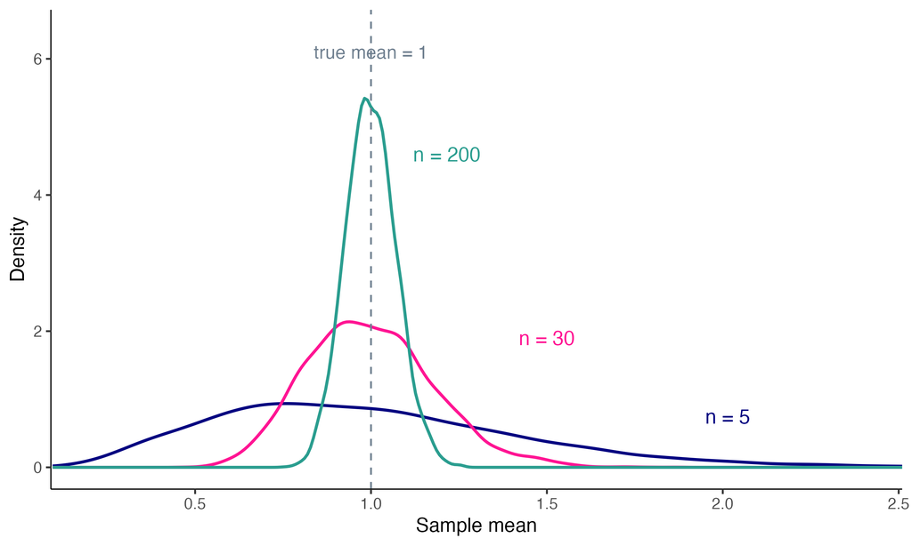

- The same population, sampled at $n = 5$, $n = 30$, and $n = 200$, with 5000 samples at each size
- All three pile up on the same true mean.
- Nothing about the population changed here.

## Bias: Is the Arrow Aimed Right?

The **bias** of an estimator is how far off it is on average across repeated samples:

$$\operatorname{Bias}(\hat\theta) = E[\hat\theta] - \theta$$

The sample mean is **unbiased** for $E[Y]$.
$$E[\bar Y_n] = \frac{1}{n} \sum_{i=1}^{n} E[Y_i] = \frac{1}{n}\,n\,\mu = \mu$$

- On average, over many samples, the sample mean lands right on the population expected value.
- Unbiasedness says nothing about any specific sample. Your particular estimate can still be badly wrong.

## Sampling Variance: How Wide Is the Spread?

Start with V2 to pull the $1/n$ out, then V5 to split the variance of the sum. Independence kills every cross term:

$$\begin{align*}
\operatorname{Var}(\bar Y_n)
&= \operatorname{Var}\left(\frac{1}{n}\sum_{i=1}^n Y_i\right) \\
&= \frac{1}{n^2}\operatorname{Var}\left(\sum_{i=1}^n Y_i\right) \\
&= \frac{1}{n^2}\sum_{i=1}^n \operatorname{Var}(Y_i) \\
&= \frac{1}{n^2}\,n\,\sigma^2 \;=\; \frac{\sigma^2}{n}
\end{align*}$$

- The $1/n$ came out **squared** by V2
- The covariance terms in V5 vanished only because the draws are independent.
- More data shrinks the sampling variance toward zero.

## The Standard Error

The **standard error** is the standard deviation of the sampling distribution:

$$\operatorname{se}(\bar Y_n) = \sqrt{\operatorname{Var}(\bar Y_n)} = \frac{\sigma}{\sqrt{n}}$$

- It reports the typical size of estimation error, in the units of $Y$

# Large Sample Theory

## Large Sample Theory

So far, we have been thinking about the sampling distribution of $\bar Y_n$ for a fixed $n$ across repeated samples.

A different thought experiment is to imagine drawing a single sample, but letting $n$ grow.

## The Law of Large Numbers

The sample mean **converges** to the population mean as the sample grows:

$$\bar Y_n \;\xrightarrow{\;p\;}\; E[Y]
\qquad \text{as } n \to \infty$$

The sampling variance $\sigma^2/n$ collapses to zero as n grows

## Watching the LLN Work

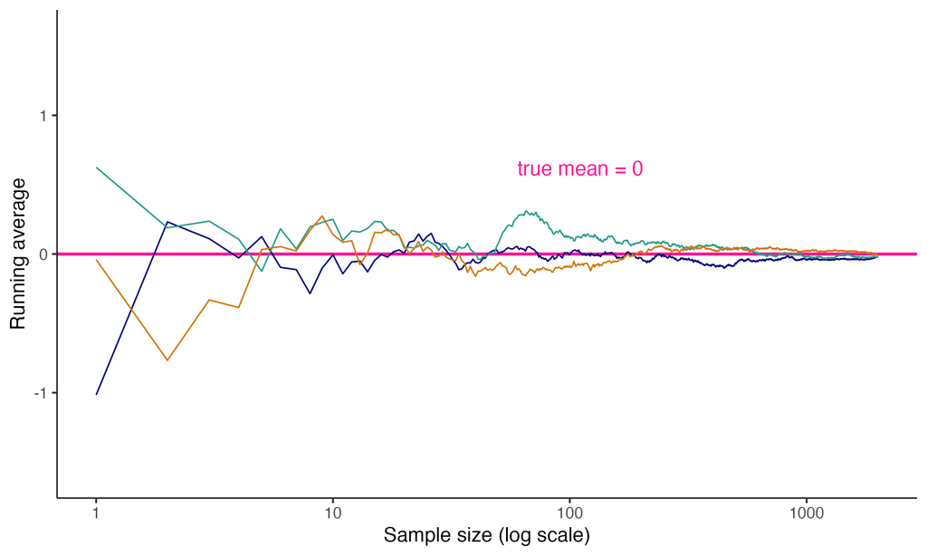

- Three running averages, each recomputed as we add draws, with the horizontal axis on a log scale
- Early on they wander. As $n$ grows every path is squeezed onto the true mean of $0$.

## The Central Limit Theorem

The LLN says $\bar Y_n$ lands on $\mu$. The CLT tells us the **shape** of the distribution around it:

$$\sqrt{n}\,\frac{\bar Y_n - \mu}{\sigma}
\;\xrightarrow{\;d\;}\; N(0, 1)$$

Under weak conditions on the underlying random variable, standardized sample means are distributed approximately **Normal** as $n$ grows

- For large $n$, $\;\bar Y_n \approx N(\mu, \sigma^2 / n)$

## The CLT

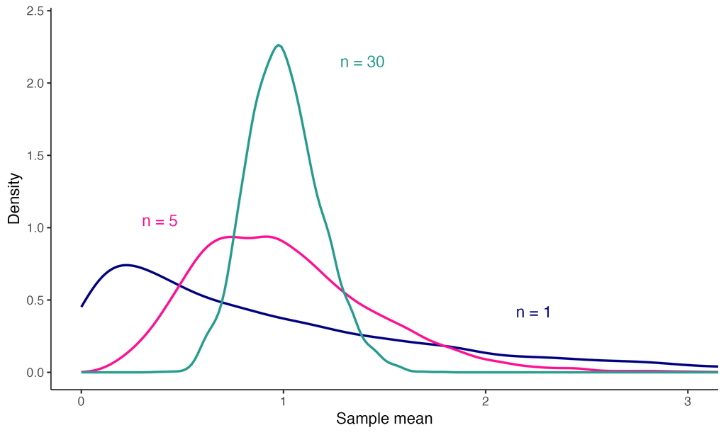

- The population here is right-skewed, an Exponential
- At $n = 1$ it inherits the skew. By $n = 30$ it is tight, symmetric, and bell-shaped.

## Watching Both Theorems in R

```r
pacman::p_load(data.table, ggplot2)
set.seed(20260814)

# 5000 sample means of size n = 30, from a
# right-skewed Exponential(1) population
sims <- data.table(
  xbar = replicate(
    5000, mean(rexp(30, rate = 1))))

# the LLN in one number: close to the
# population mean of 1
sims[, mean(xbar)]

# the CLT in one picture: bell-shaped
p <- ggplot(sims, aes(xbar)) +
  geom_histogram(bins = 30,
    fill = "#000080")
p   # draw the histogram
```

[output not shown]

## Recap

- An estimand is a feature of the population or DGP.
- An estimator is a strategy for estimating the value of the estimand from a sample of observations.
- The value of the estimator (the estimate) is a random variable, and its distribution across repeated samples is the **sampling distribution**
- The sample mean is **unbiased**, with sampling variance $\sigma^2/n$ and standard error $\sigma/\sqrt{n}$
- The **LLN** says sample averages converge to population means as n increases.
- The **CLT** says standardized averages are distributed approximately **Normal** as $n$ grows, even if the population is not Normal.